# Unit 3 Project

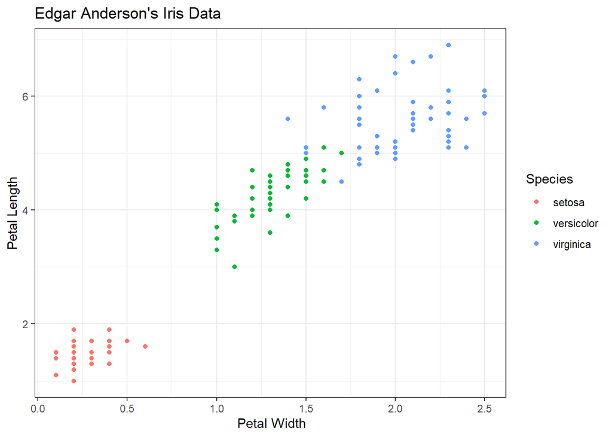

```r
ggplot(iris, aes(x = Petal.Width, y = Petal.Length, color = Species)) + geom_point() + labs(title = "Edgar Anderson's Iris Data",
                                                                                            x = " Petal Width", y = "Petal Length") + theme_bw()
```

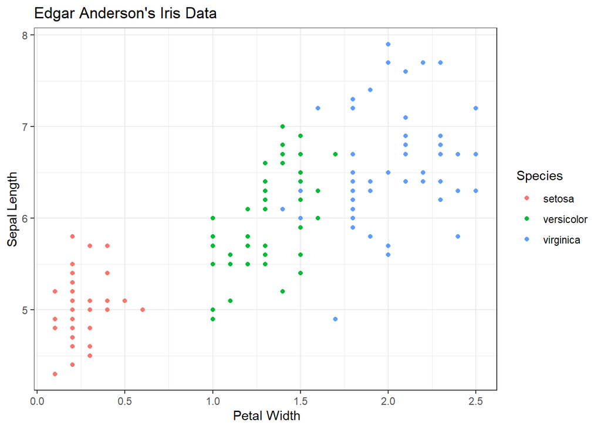

```r
ggplot(iris, aes(x = Petal.Width, y = Sepal.Length, color = Species)) + geom_point() + labs(title = "Edgar Anderson's Iris Data",
                                                                                            x = " Petal Width", y = "Sepal Length") + theme_bw()
```

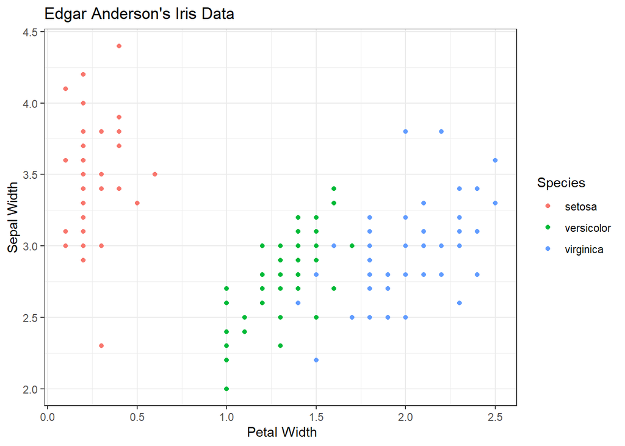

```r
ggplot(iris, aes(x = Petal.Width, y = Sepal.Width, color = Species)) + geom_point() + labs(title = "Edgar Anderson's Iris Data",
                                                                                            x = " Petal Width", y = "Sepal Width") + theme_bw()
```

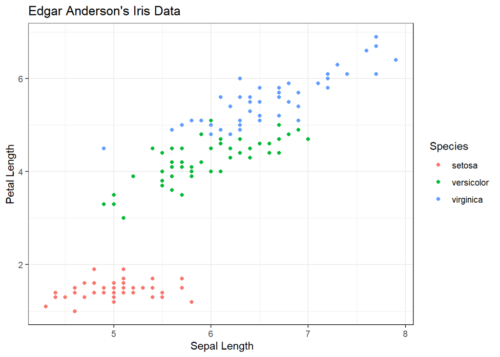

```r
ggplot(iris, aes(x = Sepal.Length, y = Petal.Length, color = Species)) + geom_point() + labs(title = "Edgar Anderson's Iris Data",
                                                                                            x = " Sepal Length", y = "Petal Length") + theme_bw()
```

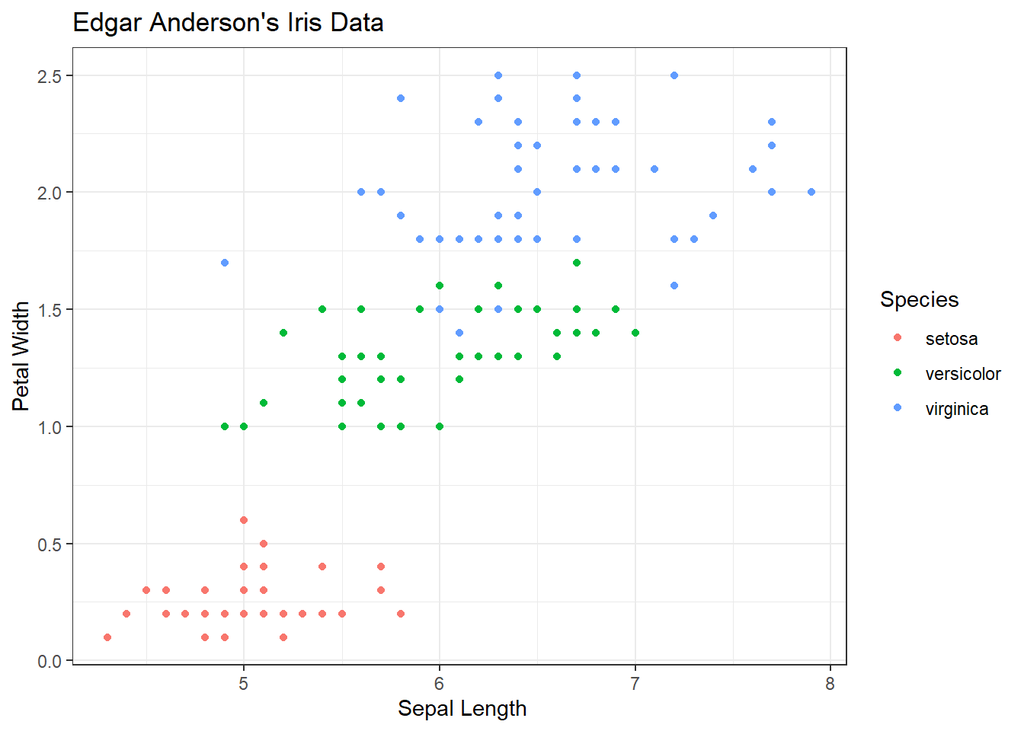

```r
ggplot(iris, aes(x = Sepal.Length, y = Petal.Width, color = Species)) + geom_point() + labs(title = "Edgar Anderson's Iris Data",
                                                                                             x = " Sepal Length", y = "Petal Width") + theme_bw()
```

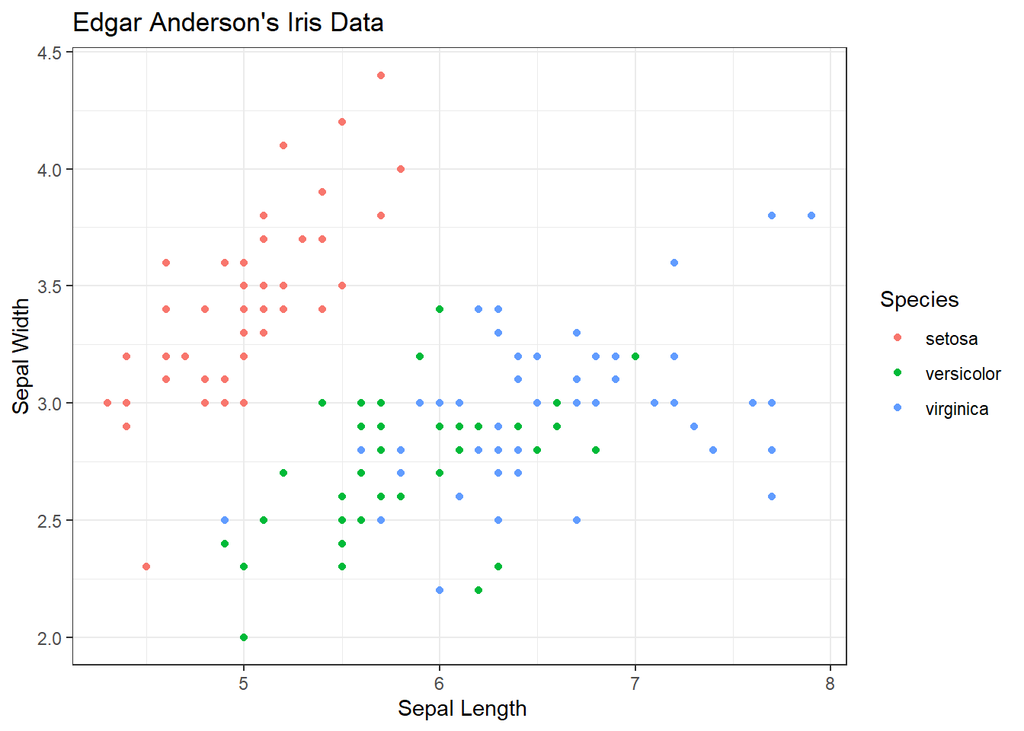

```r
ggplot(iris, aes(x = Sepal.Length, y = Sepal.Width, color = Species)) + geom_point() + labs(title = "Edgar Anderson's Iris Data",
                                                                                             x = " Sepal Length", y = "Sepal Width") + theme_bw()
```

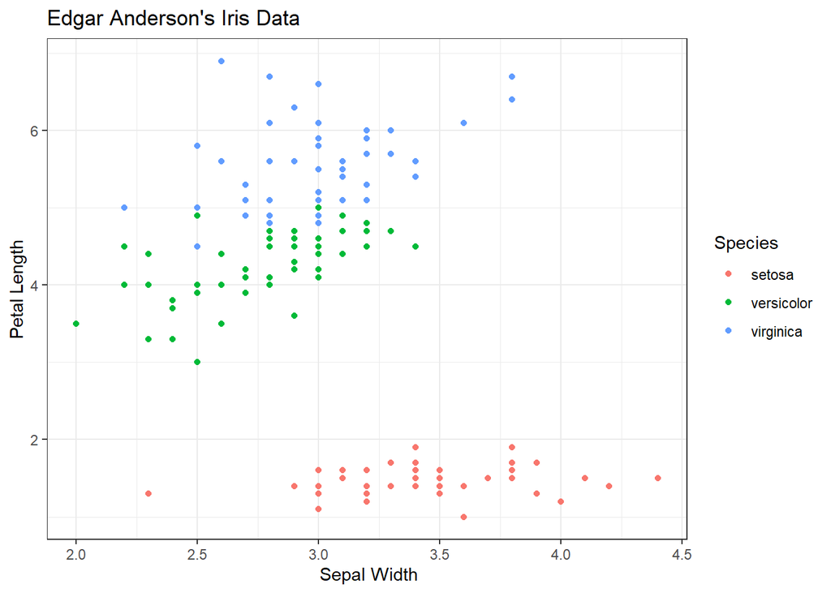

```r
ggplot(iris, aes(x = Sepal.Width, y = Petal.Length, color = Species)) + geom_point() + labs(title = "Edgar Anderson's Iris Data",
                                                                                             x = " Sepal Width", y = "Petal Length") + theme_bw()
```

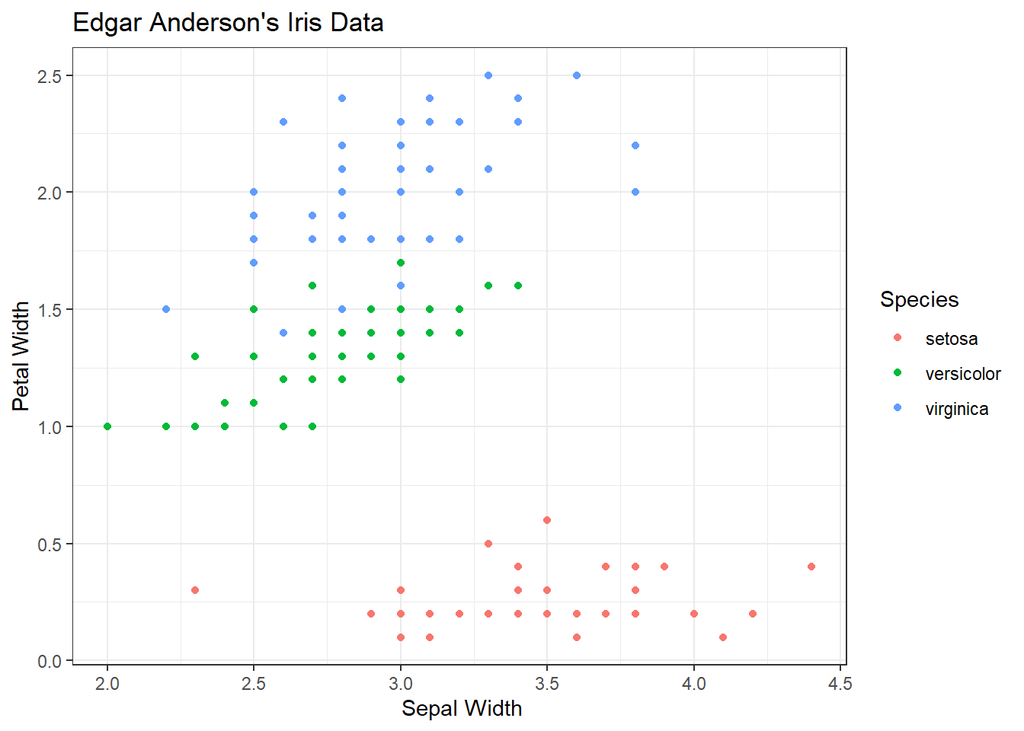

```r
ggplot(iris, aes(x = Sepal.Width, y = Petal.Width, color = Species)) + geom_point() + labs(title = "Edgar Anderson's Iris Data",
                                                                                            x = " Sepal Width", y = "Petal Width") + theme_bw()
```

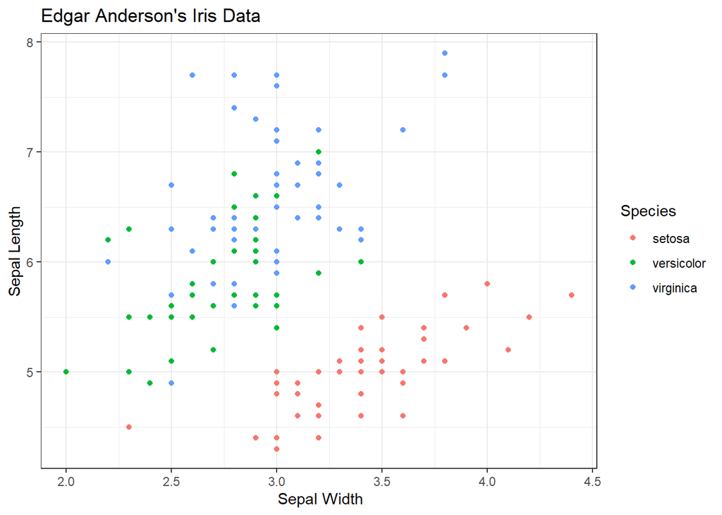

```r
ggplot(iris, aes(x = Sepal.Width, y = Sepal.Length, color = Species)) + geom_point() + labs(title = "Edgar Anderson's Iris Data",
                                                                                            x = " Sepal Width", y = "Sepal Length") + theme_bw()
```

## Question 3: Using only two of each sets of measurements on irises and discriminant analyses, which two of them give the best predictions of species as scored by Edgar Anderson? How much do these two sets of measurements differ, and how do they compare with the other sets of measurements?

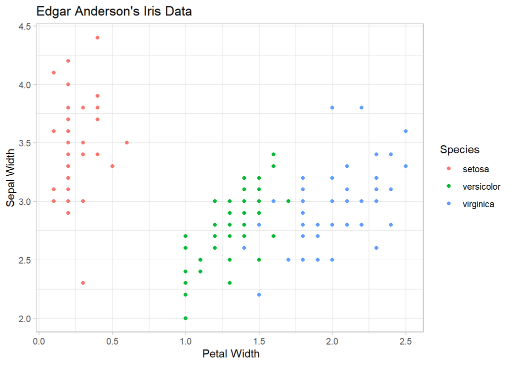

```r
ggplot(iris, aes(x = Petal.Width, y = Sepal.Width, color = Species)) + geom_point() + labs(title = "Edgar Anderson's Iris Data",
                                                                                           x = " Petal Width", y = "Sepal Width") + theme_light()
```

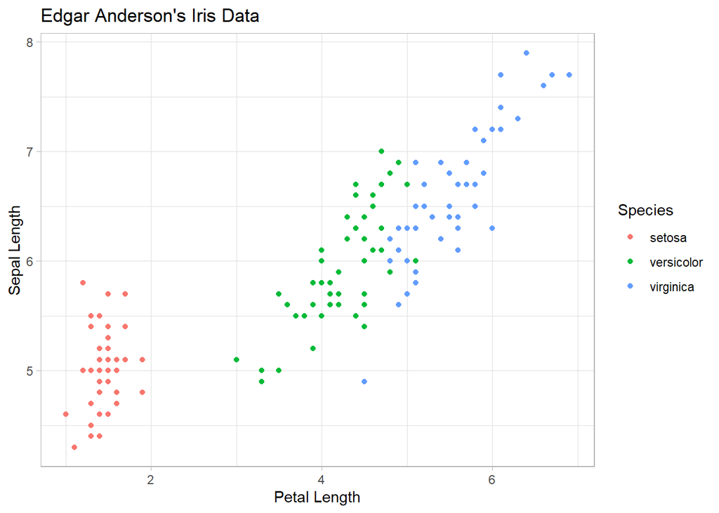

```r
ggplot(iris, aes(x = Petal.Length, y = Sepal.Length, color = Species)) +
  geom_point() + labs(title = "Edgar Anderson's Iris Data",
                      x = "Petal Length", y = "Sepal Length") + theme_light()
```

## Question 4:What data did you use to evaluate which two measurements gave the best predictions of species? Based on this data, are you confident in Edgar Anderson’s predictions? Why or why not?

# Part II: Geographical and temporal data

```r
library(tidyverse)
library(ggplot2)
library(maps)
library(dismo)
get.gbif <- function (genus, species, na.rm=TRUE, crop=TRUE)
{
  #GBIF query
  gps <- gbif(genus, species, geo=FALSE)
  #drop NA entries; note that this option is visited only with na.rm=TRUE
  if(na.rm){gps <- subset(gps, !is.na(lon) & !is.na(lat))}
  if(crop){
    keep <- c(which(colnames(gps)=="species"),which(colnames(gps)=="lat"),which(colnames(gps)=="lon"),
              which(colnames(gps)=="month"))
    gps <- gps[keep]
  }
  return(gps)
}

ggplot2::theme_set(theme_bw())

world.map <- map_data(map = "world")
us.map <- map_data(map = "usa")
```

## Question 1

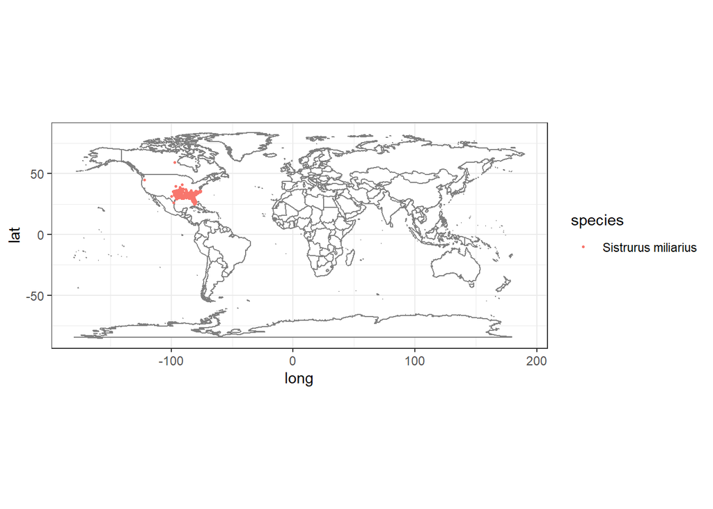

```r
snake_gps <- read_csv("0005347-260226173443078.csv")

rattlesnakes <- get.gbif("Sistrurus", "miliarius")

write_csv(rattlesnakes, file = "0005347-260226173443078.csv", col_names =  TRUE)


ggplot(world.map, aes(long, lat, group = group)) + geom_polygon(fill = "white", colour = "grey50") + coord_quickmap() + geom_point(data = snake_gps,
                                                                                                                                   mapping = aes(x = lon, y = lat, group = species, color = species), size = 0.5)
```

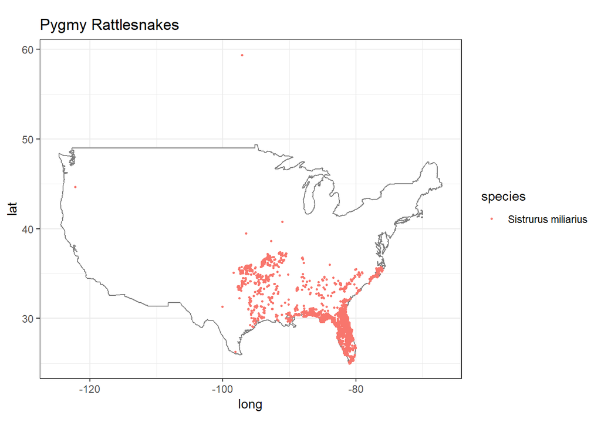

```r
ggplot(us.map, aes(long, lat, group = group)) + geom_polygon(fill = "white", colour = "grey50") + coord_quickmap() + geom_point(data = snake_gps,                                                    mapping = aes(x = lon, y = lat, group = species, color = species), size = 0.5) + labs(title = "Pygmy Rattlesnakes")
```

## Question 2

## Question 3

## Question 4

## Question 5

# Part III: Chromosomal data

## Question 1

## Question 2

## Question 3

# Part IV: Producing a scientific argument

## Question 1